# Ch3: Linear Regression

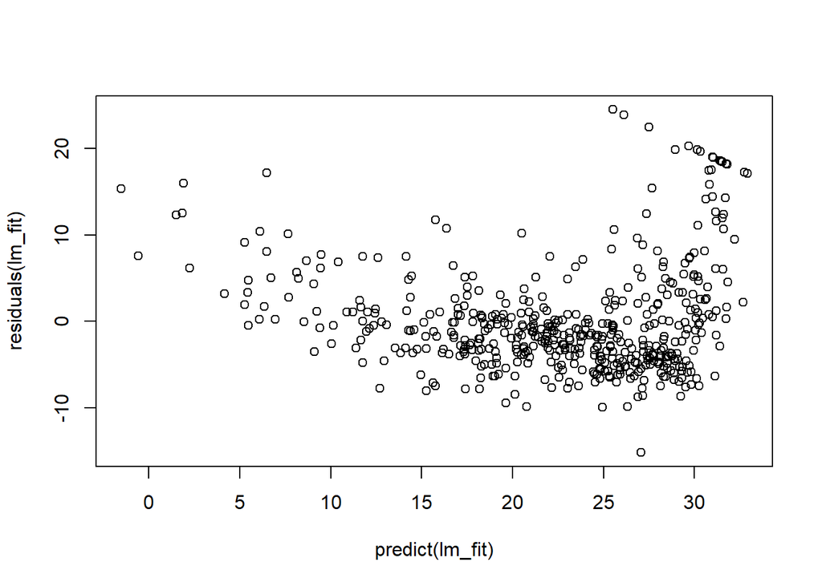

```r
plot(predict(lm_fit), residuals(lm_fit)) # compute the residuals from a linear regression fit using residuals()
```

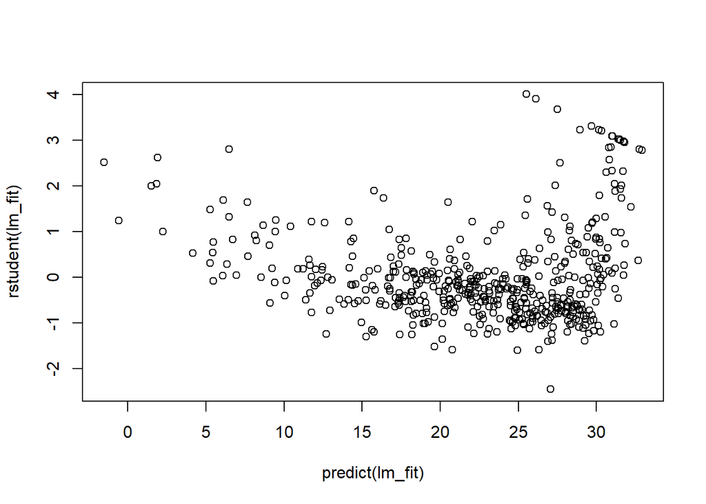

```r
plot(predict(lm_fit), rstudent(lm_fit)) # rstudent() will return the studentized residuals,
```

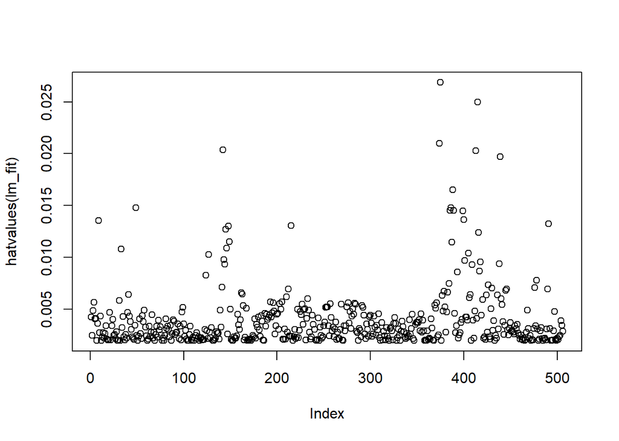

```r
# On the basis of the residual plots, there is some evidence of non-linearity.

plot(hatvalues(lm_fit)) # computes leverage statistics for any number of predictors
```

```r
which.max(hatvalues(lm_fit)) # tells us which observation has the largest leverage statistic
```

```
## 375
## 375
```

## Looking at the diagnostic plots in more detail.

### Residual plot

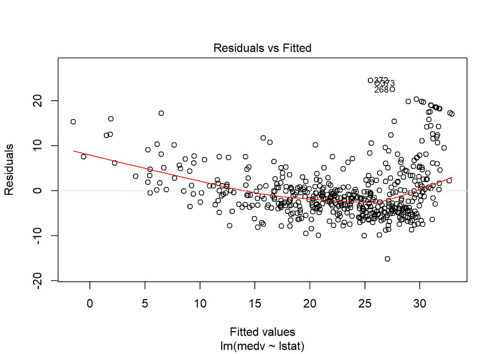

```r
plot(lm_fit, which = 1)
```

The first plot is a **residual plot** is a plot of the residuals (actual y - predicted y) versus the predicted values of y. Ideally, the residual plot will show **no discernible pattern**. The red line is a smooth fit to the residuals that is displayed in order to make it easier to identify any trends. The residual plot is used to check:

- **that there is a straight-line relationship** between the predictors and the response. The plot above shows a U-shape, which provides an indication of non-linearity in the data. Other things to look for: any trend in the residuals; “funneling” phenomenon (when the distribution of the residuals is quite well concentrated around 0 for small fitted values, but they get more and more spread out as the fitted values increase, this indicates “increasing variance”).

If the true relationship is far from linear, then virtually all of the conclusions that we draw from the fit are suspect and the prediction accuracy of the model can be significantly reduced.

What to do if a non-linear relationship is indicated by the residual plot? Use non-linear transformations of the predictors, such as logX, √X, and X^2, in the regression model. For example, fitting a quadratic removes the trend shown in the residuals plot (see below). Alternatively, use more advanced non-linear alternatives to linear regression.

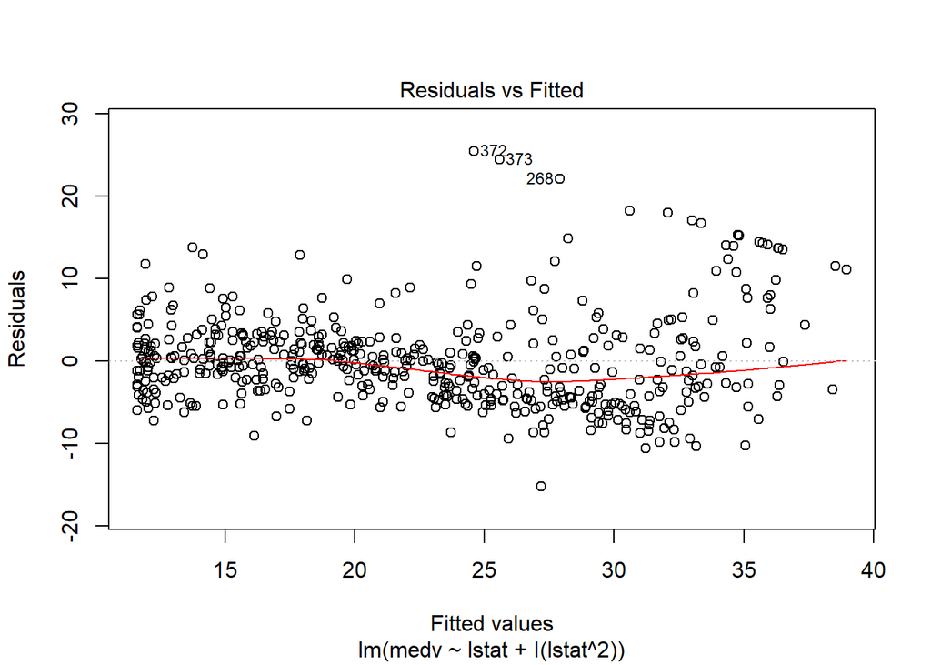

```r
lm_fit_quad <- lm(medv ∼ lstat + I(lstat^2), data=Boston)
plot(lm_fit_quad, which = 1)
```

- **correlation of error terms**. An important assumption of the linear regression model is that the error terms are uncorrelated. If the errors are uncorrelated, then the fact that $\epsilon_i$ is positive provides little or no information about the sign of $\epsilon_{i+1}$. If the errors are uncorrelated, then there should be no discernible pattern. On the other hand, if the error terms are positively correlated, then adjacent residuals may have similar values (tracking in the residuals). Correlation of error terms frequently occurs in the context of time series data. Why does this matter? The standard errors that are calculated for the estimated regression coefficients or the fitted y values are based on the assumption of uncorrelated error terms. If there is correlation among the error terms, then the estimated standard errors will tend to underestimate the true standard errors and as a result confidence and prediction intervals will be narrower than they should be (the model will be overconfident).
- **non-constant variance of error terms** (or heteroscedasticity). Another important assumption of the linear regression model is that the error terms have a constant variance, $Var(\epsilon_i) = \sigma^2$. The standard errors, confidence intervals, and hypothesis tests associated with the linear model rely upon this assumption. Unfortunately, it is often the case that the variances of the error terms are non-constant (e.g., the variances of the error terms may increase with the value of the response, see below). You can identify non-constant variances in the errors from the presence of a **funnel shape** in the residual plot.One possible solution to this problem is to transform the response Y using a concave function such as $logY$ or $\sqrt{Y}$. These transformation result in a greater amount of shrinkage of the larger responses, leading to a reduction in heteroscedasticity.

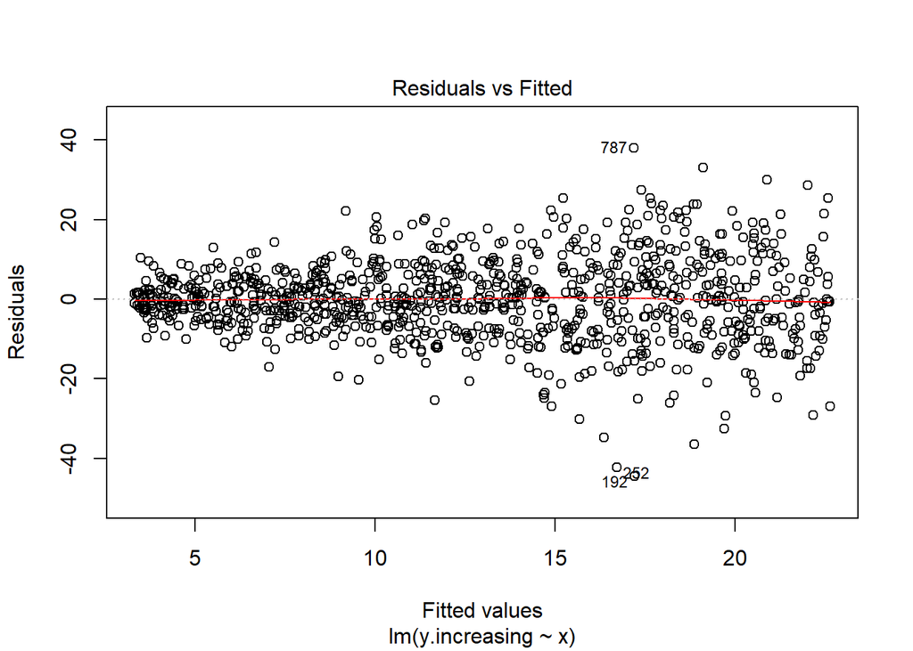

```r
n <- 1000      # sample size
x <- runif(n, min = 0, max = 100)
y.increasing <- 3 + 0.2 * x + (1 + x / 25) * rnorm(n, sd = 3)
lm.increasing <- lm(y.increasing ~ x)
plot(lm.increasing, which = 1)
```

- **identify outliers**. An **outlier** is a point for which **$y_i$ is far from the value predicted by the model** In practice, it can be difficult to decide how large a residual needs to be before we consider the point to be an outlier. To address this problem, instead of plotting the residuals, you can plot the **studentized residuals**. Observations whose absolute value of studentized residuals are **greater than 3** are possible outliers.

It is typical for an outlier that does not have an unusual predictor value to have little effect on the least squares fit. However, even if an outlier does not have much effect on the least squares fit, it can cause other problems (e.g., including or excluding an outlier can have a substantial impact on all confidence intervals, p-values and the $R^2$). If you believe that an outlier has occurred because of an error in data collection or recording, then one solution is to remove the observation. However, care should be taken, since an outlier may instead indicate a deficiency with the model, such as a missing predictor.

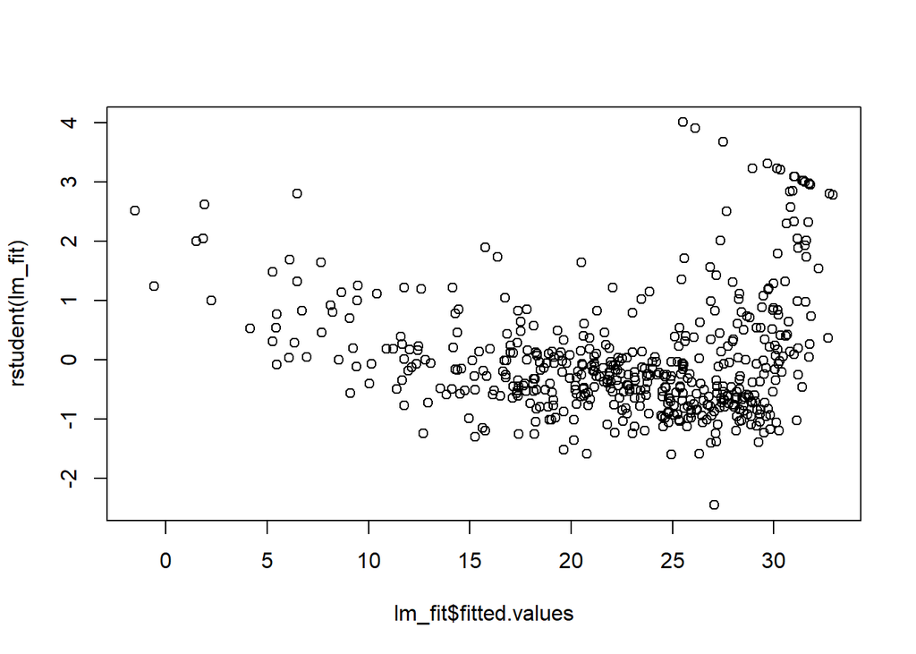

```r
# plot(rstudent(lm_fit)) # studentized residuals

plot(lm_fit$fitted.values,rstudent(lm_fit))# studentized residuals
```

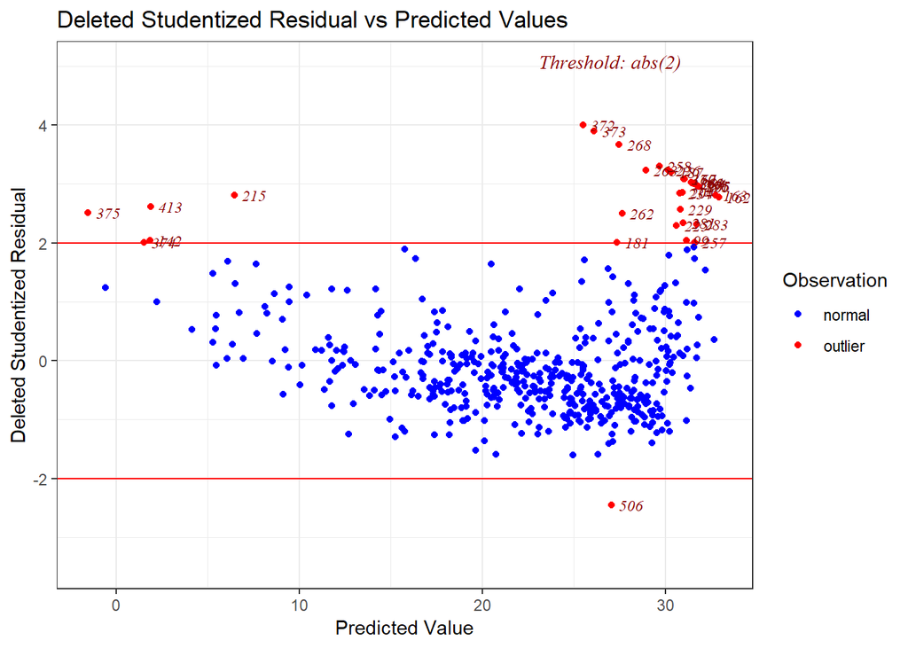

```r
ols_plot_resid_stud_fit(lm_fit)# externally studentized residuals
```

A perfect residual plot is displayed below.

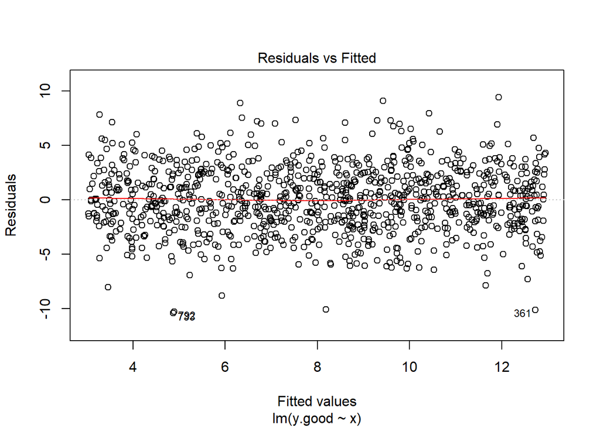

```r
n <- 1000      # sample size
x <- runif(n, min = 0, max = 100)
y.good <- 3 + 0.1 * x + rnorm(n, sd = 3)

lm.good <- lm(y.good ~ x)

plot(lm.good, which = 1)
```

The third plot is the Scale-Location plot. The “Residuals vs Fitted” and “Scale-Location” charts are essentially the same, and show if there is a trend to the residuals.

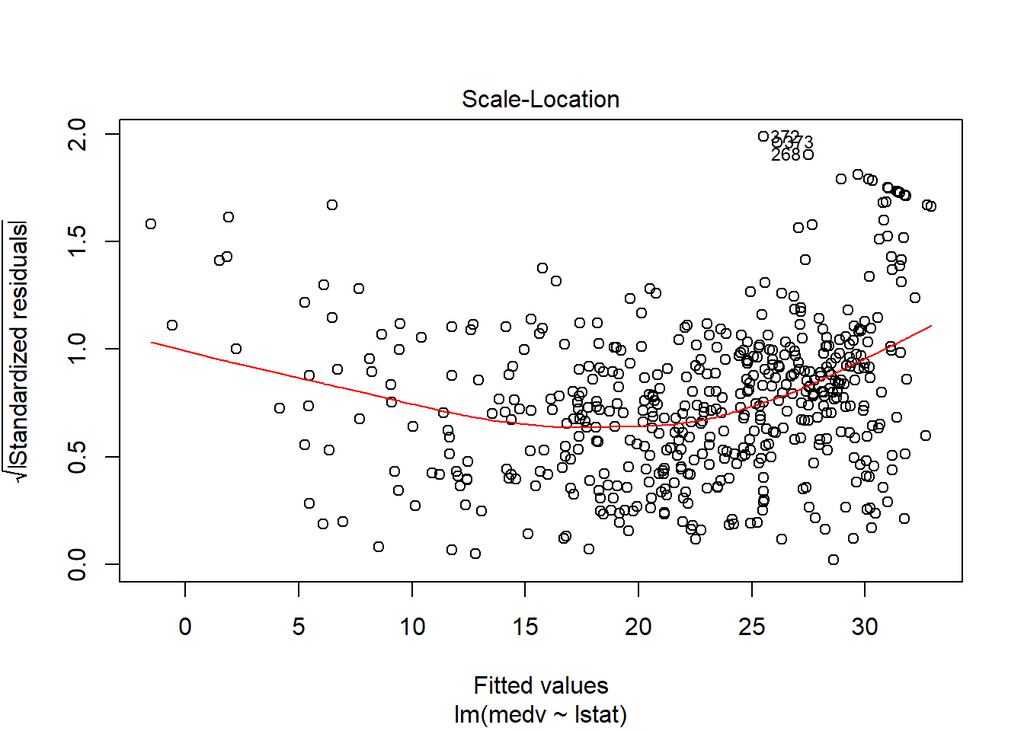

```r
plot(lm_fit, which = 3)
```

### Normal QQ plot

The second plot is the **Normal QQ plot** that is used to assess whether the **residuals are normally distributed**. There can be problems if the residuals look far from normal. In particular, if the residual tend to be larger in magnitude than what we would expect from the normal distribution, then our p-values and confidence intervals may be too optimisitic.

To address this you can try transforming y (e.g., use log(y)). But it seems like non-normally distributed residuals can indicate other problems with the model (e.g., outliers could be a problem or the linear model assumption is not correct).

In our Normal QQ plot the residuals deviate from the diagonal line in both the upper and lower tail.

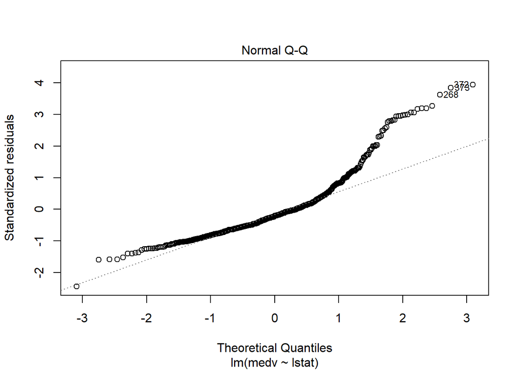

```r
plot(lm_fit, which = 2)
```

An ideal Normal QQ plot is displayed below.

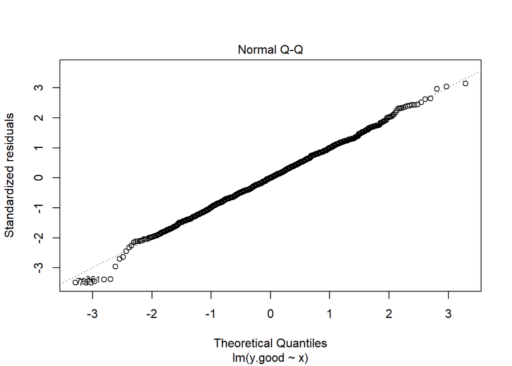

```r
plot(lm.good, which = 2)
```

### Leverage

Observations with **high leverage have an unusual value for $x_i$** (as opposed to outliers, which have an unusual value for $y_i$). It is important to identify high leverage observations because they **tend to have a sizable impact on the estimated regression line**. It is cause for concern if the least squares line is heavily affected by just a couple of observations, because any problems with these points may invalidate the entire fit. In a simple linear regression, high leverage observations are fairly easy to identify, since we can simply look for observations for which the predictor value is outside of the normal range of the observations. But in a multiple linear regression with many predictors, it is possible to have an observation that is well within the range of each individual predictor’s values, but that is unusual in terms of the full set of predictors. In order to quantify an observation’s leverage, we compute the **leverage statistic**. A **large value** of this statistic **indicates an observation with high leverage**. If a given observation has a leverage statistic that greatly exceeds $(p+1)/n$ (where $p$ is the number of predictors and $n$ is the total number of observations), then we may suspect that the corresponding point has high leverage.

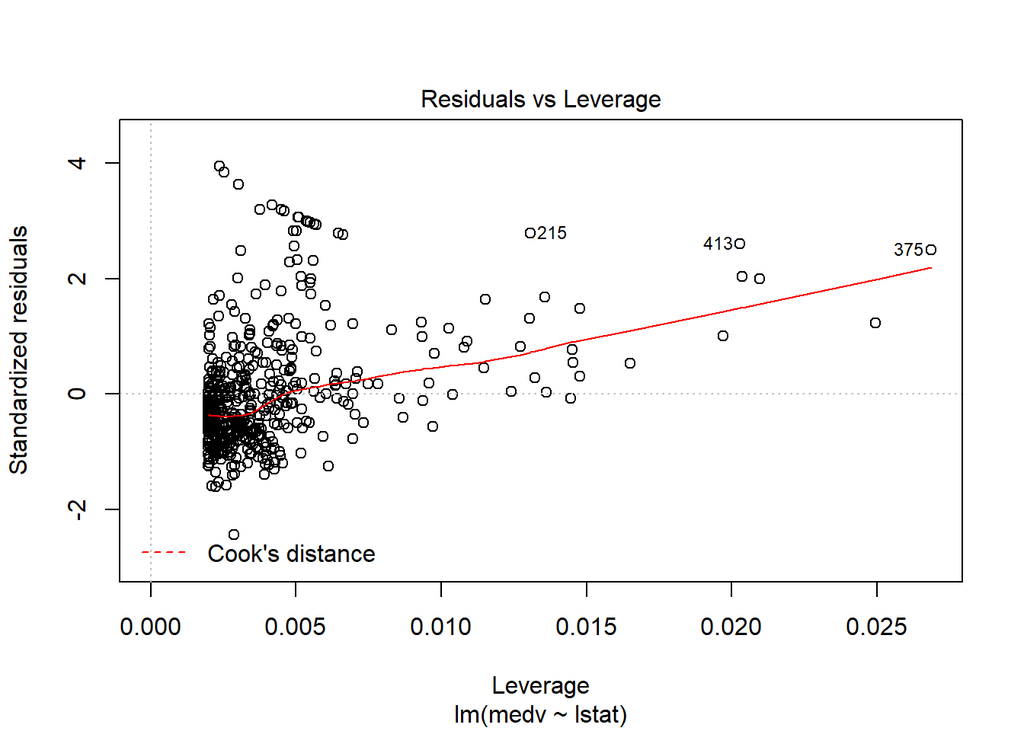

```r
plot(lm_fit, which = 5)
```

Alternative plotting option that uses studentized residuals, rather than standardized residuals:

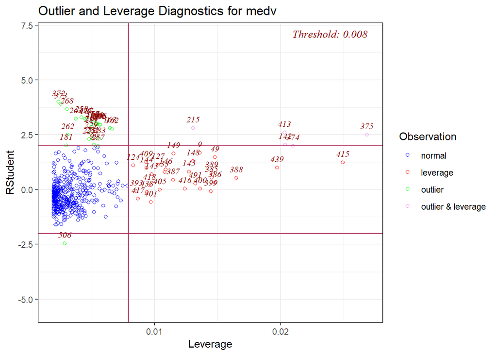

```r
ols_plot_resid_lev(lm_fit)
```

# 3.6.3 Multiple Linear Regression

Using the `lm()` function to fit a multiple linear regression model. The syntax is `lm(y ∼ x1 + x2 + x3, data)`, where `y` is the response, `x1, x2, x3` are the predictors, and `data` is the data set in which these two variables are kept.

```r
lm_fit <- lm(medv ∼ lstat + age, data = Boston) # fitting multiple linear regression model with lstat and age as predictors and medv as the response
summary(lm_fit)
```

```
##
## Call:
## lm(formula = medv ~ lstat + age, data = Boston)
##
## Residuals:
##     Min      1Q  Median      3Q     Max
## -15.981  -3.978  -1.283   1.968  23.158
##
## Coefficients:
##             Estimate Std. Error t value Pr(>|t|)
## (Intercept) 33.22276    0.73085  45.458  < 2e-16 ***
## lstat       -1.03207    0.04819 -21.416  < 2e-16 ***
## age          0.03454    0.01223   2.826  0.00491 **
## ---
## Signif. codes:  0 '***' 0.001 '**' 0.01 '*' 0.05 '.' 0.1 ' ' 1
##
## Residual standard error: 6.173 on 503 degrees of freedom
## Multiple R-squared:  0.5513, Adjusted R-squared:  0.5495
## F-statistic:   309 on 2 and 503 DF,  p-value: < 2.2e-16
```

```r
lm_fit_all <- lm(medv ∼., data = Boston) # fitting multiple linear regression model with ALL predictors and medv as the response
summary(lm_fit_all)
```

```
##
## Call:
## lm(formula = medv ~ ., data = Boston)
##
## Residuals:
##     Min      1Q  Median      3Q     Max
## -15.595  -2.730  -0.518   1.777  26.199
##
## Coefficients:
##               Estimate Std. Error t value Pr(>|t|)
## (Intercept)  3.646e+01  5.103e+00   7.144 3.28e-12 ***
## crim        -1.080e-01  3.286e-02  -3.287 0.001087 **
## zn           4.642e-02  1.373e-02   3.382 0.000778 ***
## indus        2.056e-02  6.150e-02   0.334 0.738288
## chas         2.687e+00  8.616e-01   3.118 0.001925 **
## nox         -1.777e+01  3.820e+00  -4.651 4.25e-06 ***
## rm           3.810e+00  4.179e-01   9.116  < 2e-16 ***
## age          6.922e-04  1.321e-02   0.052 0.958229
## dis         -1.476e+00  1.995e-01  -7.398 6.01e-13 ***
## rad          3.060e-01  6.635e-02   4.613 5.07e-06 ***
## tax         -1.233e-02  3.760e-03  -3.280 0.001112 **
## ptratio     -9.527e-01  1.308e-01  -7.283 1.31e-12 ***
## black        9.312e-03  2.686e-03   3.467 0.000573 ***
## lstat       -5.248e-01  5.072e-02 -10.347  < 2e-16 ***
## ---
## Signif. codes:  0 '***' 0.001 '**' 0.01 '*' 0.05 '.' 0.1 ' ' 1
##
## Residual standard error: 4.745 on 492 degrees of freedom
## Multiple R-squared:  0.7406, Adjusted R-squared:  0.7338
## F-statistic: 108.1 on 13 and 492 DF,  p-value: < 2.2e-16
```

```r
summary(lm_fit_all)$r.sq # gives the R2
```

```
## [1] 0.7406427
```

```r
summary(lm_fit_all)$sigma # gives the RSE (Residual Standard Error: Roughly speaking, RSE is the average amount that the response will deviate from the true regression line).
```

```
## [1] 4.745298
```

```r
vif(lm_fit_all) # gives variance inflation factors
```

```
##     crim       zn    indus     chas      nox       rm      age      dis
## 1.792192 2.298758 3.991596 1.073995 4.393720 1.933744 3.100826 3.955945
##      rad      tax  ptratio    black    lstat
## 7.484496 9.008554 1.799084 1.348521 2.941491
```

The **variance inflation factor (VIF)** is a way to assess **multicollinearity**. The VIF is the ratio of the variance of $\hat{\beta_j}$ when fitting the full model divided by the variance of $\hat{\beta_j}$ if fit on its own. The smallest possible value for VIF is **1**, which indicates the **complete absence of collinearity**. As a rule of thumb, a **VIF value that exceeds 5 or 10 indicates a problematic amount of collinearity**.

```r
lm_fit1 <- lm(medv ∼. -age, data = Boston) # fitting all variables EXCEPT age
summary(lm_fit1)
```

```
##
## Call:
## lm(formula = medv ~ . - age, data = Boston)
##
## Residuals:
##      Min       1Q   Median       3Q      Max
## -15.6054  -2.7313  -0.5188   1.7601  26.2243
##
## Coefficients:
##               Estimate Std. Error t value Pr(>|t|)
## (Intercept)  36.436927   5.080119   7.172 2.72e-12 ***
## crim         -0.108006   0.032832  -3.290 0.001075 **
## zn            0.046334   0.013613   3.404 0.000719 ***
## indus         0.020562   0.061433   0.335 0.737989
## chas          2.689026   0.859598   3.128 0.001863 **
## nox         -17.713540   3.679308  -4.814 1.97e-06 ***
## rm            3.814394   0.408480   9.338  < 2e-16 ***
## dis          -1.478612   0.190611  -7.757 5.03e-14 ***
## rad           0.305786   0.066089   4.627 4.75e-06 ***
## tax          -0.012329   0.003755  -3.283 0.001099 **
## ptratio      -0.952211   0.130294  -7.308 1.10e-12 ***
## black         0.009321   0.002678   3.481 0.000544 ***
## lstat        -0.523852   0.047625 -10.999  < 2e-16 ***
## ---
## Signif. codes:  0 '***' 0.001 '**' 0.01 '*' 0.05 '.' 0.1 ' ' 1
##
## Residual standard error: 4.74 on 493 degrees of freedom
## Multiple R-squared:  0.7406, Adjusted R-squared:  0.7343
## F-statistic: 117.3 on 12 and 493 DF,  p-value: < 2.2e-16
```

```r
# alternatively using update() function:
lm_fit1 <- update(lm_fit_all, ∼. -age)
```

# 3.6.4 Interaction Terms

```r
summary(lm(medv ∼ lstat*age, data = Boston)) # includes lstat, age, and the interaction term lstat×age as predictors
```

```
##
## Call:
## lm(formula = medv ~ lstat * age, data = Boston)
##
## Residuals:
##     Min      1Q  Median      3Q     Max
## -15.806  -4.045  -1.333   2.085  27.552
##
## Coefficients:
##               Estimate Std. Error t value Pr(>|t|)
## (Intercept) 36.0885359  1.4698355  24.553  < 2e-16 ***
## lstat       -1.3921168  0.1674555  -8.313 8.78e-16 ***
## age         -0.0007209  0.0198792  -0.036   0.9711
## lstat:age    0.0041560  0.0018518   2.244   0.0252 *
## ---
## Signif. codes:  0 '***' 0.001 '**' 0.01 '*' 0.05 '.' 0.1 ' ' 1
##
## Residual standard error: 6.149 on 502 degrees of freedom
## Multiple R-squared:  0.5557, Adjusted R-squared:  0.5531
## F-statistic: 209.3 on 3 and 502 DF,  p-value: < 2.2e-16
```

# 3.6.5 Non-linear Transformations of the Predictors

The `lm()` function can also accommodate non-linear transformations of the predictors. For instance, given a predictor `X`, we can create a predictor `X^2` using `I(X^2)`. The function `I()` is needed since the `^` has a special meaning in a formula; wrapping as we do allows the standard usage in R, which is to raise `X` to the power 2.

```r
lm_fit2 <- lm(medv ∼ lstat + I(lstat^2)) # regression of medv onto lstat and lstat^2
summary(lm_fit2)
```

```
##
## Call:
## lm(formula = medv ~ lstat + I(lstat^2))
##
## Residuals:
##      Min       1Q   Median       3Q      Max
## -15.2834  -3.8313  -0.5295   2.3095  25.4148
##
## Coefficients:
##              Estimate Std. Error t value Pr(>|t|)
## (Intercept) 42.862007   0.872084   49.15   <2e-16 ***
## lstat       -2.332821   0.123803  -18.84   <2e-16 ***
## I(lstat^2)   0.043547   0.003745   11.63   <2e-16 ***
## ---
## Signif. codes:  0 '***' 0.001 '**' 0.01 '*' 0.05 '.' 0.1 ' ' 1
##
## Residual standard error: 5.524 on 503 degrees of freedom
## Multiple R-squared:  0.6407, Adjusted R-squared:  0.6393
## F-statistic: 448.5 on 2 and 503 DF,  p-value: < 2.2e-16
```

```r
# The near-zero p-value associated with the quadratic term suggests that it leads to an improved model.

lm_fit <- lm(medv ∼ lstat)
anova(lm_fit, lm_fit2) # to quantify the extent to which the quadratic fit is superior to the linear fit.
```

```
## Analysis of Variance Table
##
## Model 1: medv ~ lstat
## Model 2: medv ~ lstat + I(lstat^2)
##   Res.Df   RSS Df Sum of Sq     F    Pr(>F)
## 1    504 19472
## 2    503 15347  1    4125.1 135.2 < 2.2e-16 ***
## ---
## Signif. codes:  0 '***' 0.001 '**' 0.01 '*' 0.05 '.' 0.1 ' ' 1
```

“Here Model 1 represents the linear submodel containing only one predictor, `lstat`, while Model 2 corresponds to the larger quadratic model that has two predictors, `lstat` and `lstat^2`. The `anova()` function performs a hypothesis test comparing the two models. The null hypothesis is that the two models fit the data equally well, and the alternative hypothesis is that the full model is superior. Here the F-statistic is 135 and the associated p-value is virtually zero. This provides very clear evidence that the model containing the predictors `lstat` and `lstat^2` is far superior to the model that only contains the predictor `lstat`. This is not surprising, since earlier we saw evidence for non-linearity in the relationship between `medv` and `lstat`.”

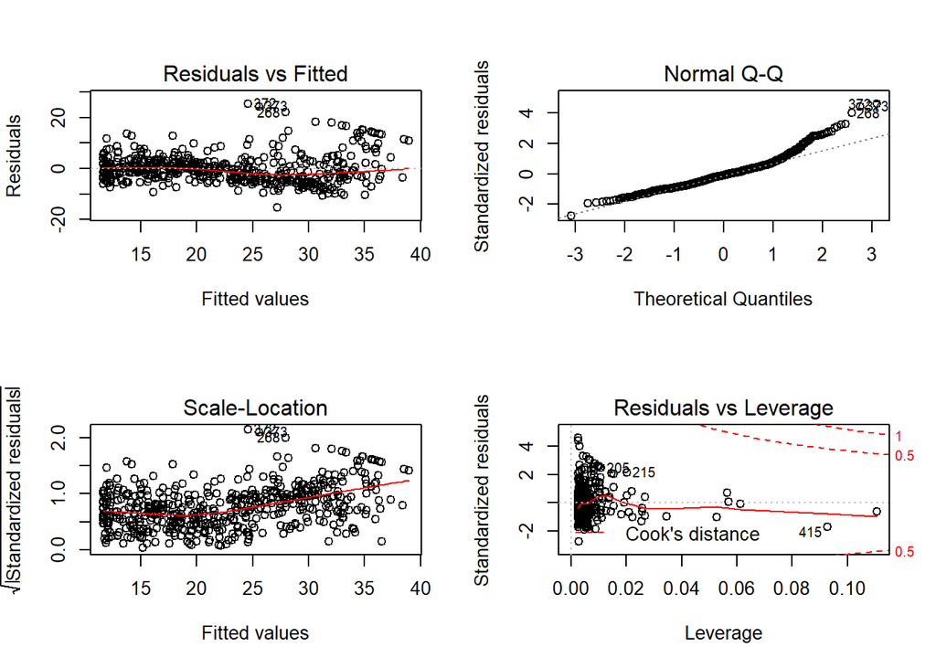

```r
par(mfrow = c(2,2))
plot(lm_fit2)
```

```r
# there is little discernible pattern in the residuals.

lm_fit5 <- lm(medv ∼ poly(lstat, 5)) # a fifth-order polynomial fit
summary(lm_fit5)
```

```
##
## Call:
## lm(formula = medv ~ poly(lstat, 5))
##
## Residuals:
##      Min       1Q   Median       3Q      Max
## -13.5433  -3.1039  -0.7052   2.0844  27.1153
##
## Coefficients:
##                  Estimate Std. Error t value Pr(>|t|)
## (Intercept)       22.5328     0.2318  97.197  < 2e-16 ***
## poly(lstat, 5)1 -152.4595     5.2148 -29.236  < 2e-16 ***
## poly(lstat, 5)2   64.2272     5.2148  12.316  < 2e-16 ***
## poly(lstat, 5)3  -27.0511     5.2148  -5.187 3.10e-07 ***
## poly(lstat, 5)4   25.4517     5.2148   4.881 1.42e-06 ***
## poly(lstat, 5)5  -19.2524     5.2148  -3.692 0.000247 ***
## ---
## Signif. codes:  0 '***' 0.001 '**' 0.01 '*' 0.05 '.' 0.1 ' ' 1
##
## Residual standard error: 5.215 on 500 degrees of freedom
## Multiple R-squared:  0.6817, Adjusted R-squared:  0.6785
## F-statistic: 214.2 on 5 and 500 DF,  p-value: < 2.2e-16
```

```r
summary(lm(medv ∼ log(rm), data = Boston)) # log transformation of rm
```

```
##
## Call:
## lm(formula = medv ~ log(rm), data = Boston)
##
## Residuals:
##     Min      1Q  Median      3Q     Max
## -19.487  -2.875  -0.104   2.837  39.816
##
## Coefficients:
##             Estimate Std. Error t value Pr(>|t|)
## (Intercept)  -76.488      5.028  -15.21   <2e-16 ***
## log(rm)       54.055      2.739   19.73   <2e-16 ***
## ---
## Signif. codes:  0 '***' 0.001 '**' 0.01 '*' 0.05 '.' 0.1 ' ' 1
##
## Residual standard error: 6.915 on 504 degrees of freedom
## Multiple R-squared:  0.4358, Adjusted R-squared:  0.4347
## F-statistic: 389.3 on 1 and 504 DF,  p-value: < 2.2e-16
```

# 3.6.6 Qualitative Predictors

Given a qualitative variable such as `Shelveloc` (which takes on 3 possible values, Bad, Medium, and Good), `R` generates dummy variables automatically.

```r
as_tibble(Carseats)
```

```
## # A tibble: 400 x 11
##    Sales CompPrice Income Advertising Population Price ShelveLoc   Age
##    <dbl>     <dbl>  <dbl>       <dbl>      <dbl> <dbl> <fct>     <dbl>
##  1  9.5        138     73          11        276   120 Bad          42
##  2 11.2        111     48          16        260    83 Good         65
##  3 10.1        113     35          10        269    80 Medium       59
##  4  7.4        117    100           4        466    97 Medium       55
##  5  4.15       141     64           3        340   128 Bad          38
##  6 10.8        124    113          13        501    72 Bad          78
##  7  6.63       115    105           0         45   108 Medium       71
##  8 11.8        136     81          15        425   120 Good         67
##  9  6.54       132    110           0        108   124 Medium       76
## 10  4.69       132    113           0        131   124 Medium       76
## # ... with 390 more rows, and 3 more variables: Education <dbl>,
## #   Urban <fct>, US <fct>
```

```r
names(Carseats)
```

```
##  [1] "Sales"       "CompPrice"   "Income"      "Advertising" "Population"
##  [6] "Price"       "ShelveLoc"   "Age"         "Education"   "Urban"
## [11] "US"
```

```r
lm_fit <- lm(Sales ∼. + Income:Advertising + Price:Age, data = Carseats) # multiple regression model that includes all predictors plus some interaction terms
summary(lm_fit)
```

```
##
## Call:
## lm(formula = Sales ~ . + Income:Advertising + Price:Age, data = Carseats)
##
## Residuals:
##     Min      1Q  Median      3Q     Max
## -2.9208 -0.7503  0.0177  0.6754  3.3413
##
## Coefficients:
##                      Estimate Std. Error t value Pr(>|t|)
## (Intercept)         6.5755654  1.0087470   6.519 2.22e-10 ***
## CompPrice           0.0929371  0.0041183  22.567  < 2e-16 ***
## Income              0.0108940  0.0026044   4.183 3.57e-05 ***
## Advertising         0.0702462  0.0226091   3.107 0.002030 **
## Population          0.0001592  0.0003679   0.433 0.665330
## Price              -0.1008064  0.0074399 -13.549  < 2e-16 ***
## ShelveLocGood       4.8486762  0.1528378  31.724  < 2e-16 ***
## ShelveLocMedium     1.9532620  0.1257682  15.531  < 2e-16 ***
## Age                -0.0579466  0.0159506  -3.633 0.000318 ***
## Education          -0.0208525  0.0196131  -1.063 0.288361
## UrbanYes            0.1401597  0.1124019   1.247 0.213171
## USYes              -0.1575571  0.1489234  -1.058 0.290729
## Income:Advertising  0.0007510  0.0002784   2.698 0.007290 **
## Price:Age           0.0001068  0.0001333   0.801 0.423812
## ---
## Signif. codes:  0 '***' 0.001 '**' 0.01 '*' 0.05 '.' 0.1 ' ' 1
##
## Residual standard error: 1.011 on 386 degrees of freedom
## Multiple R-squared:  0.8761, Adjusted R-squared:  0.8719
## F-statistic:   210 on 13 and 386 DF,  p-value: < 2.2e-16
```

```r
contrasts(Carseats$ShelveLoc)
```

```
##        Good Medium
## Bad       0      0
## Good      1      0
## Medium    0      1
```

Alternatively, converting `Shelveloc` to an ordered factor to take into account the order of the shelf locations:

```r
Carseats$ShelveLoc <- factor(Carseats$ShelveLoc, levels=c("Bad", "Medium", "Good"), ordered=TRUE) # converting ShelveLoc to an ordered factor
# you can tell ShelveLoc is now an ordered factor because of the '<' signs in Levels (Levels: Bad < Medium < Good)

lm_fit_ord <- lm(Sales ∼. + Income:Advertising + Price:Age, data = Carseats) # multiple regression model that includes all predictors plus some interaction terms
summary(lm_fit_ord)
```

```
##
## Call:
## lm(formula = Sales ~ . + Income:Advertising + Price:Age, data = Carseats)
##
## Residuals:
##     Min      1Q  Median      3Q     Max
## -2.9208 -0.7503  0.0177  0.6754  3.3413
##
## Coefficients:
##                      Estimate Std. Error t value Pr(>|t|)
## (Intercept)         8.8428782  0.9968929   8.870  < 2e-16 ***
## CompPrice           0.0929371  0.0041183  22.567  < 2e-16 ***
## Income              0.0108940  0.0026044   4.183 3.57e-05 ***
## Advertising         0.0702462  0.0226091   3.107 0.002030 **
## Population          0.0001592  0.0003679   0.433 0.665330
## Price              -0.1008064  0.0074399 -13.549  < 2e-16 ***
## ShelveLoc.L         3.4285318  0.1080727  31.724  < 2e-16 ***
## ShelveLoc.Q         0.3846320  0.0836845   4.596 5.84e-06 ***
## Age                -0.0579466  0.0159506  -3.633 0.000318 ***
## Education          -0.0208525  0.0196131  -1.063 0.288361
## UrbanYes            0.1401597  0.1124019   1.247 0.213171
## USYes              -0.1575571  0.1489234  -1.058 0.290729
## Income:Advertising  0.0007510  0.0002784   2.698 0.007290 **
## Price:Age           0.0001068  0.0001333   0.801 0.423812
## ---
## Signif. codes:  0 '***' 0.001 '**' 0.01 '*' 0.05 '.' 0.1 ' ' 1
##
## Residual standard error: 1.011 on 386 degrees of freedom
## Multiple R-squared:  0.8761, Adjusted R-squared:  0.8719
## F-statistic:   210 on 13 and 386 DF,  p-value: < 2.2e-16
```

```r
contrasts(Carseats$ShelveLoc)
```

```
##                 .L         .Q
## [1,] -7.071068e-01  0.4082483
## [2,] -7.850462e-17 -0.8164966
## [3,]  7.071068e-01  0.4082483
```

Ordered factors are automatically represented via orthogonal polynomials for linear regression. Now the intercept specifies the value of $y$ at the mean factor level; the $L$ (linear) parameter gives a measure of the linear trend ; $Q$ specifies the quadratic term (can also end up with cubic etc. terms).

# 3.6.7 Writing Functions

```r
LoadLibraries <- function (){ # creating the function
  library (ISLR)
  library (MASS)
  print (" The libraries have been loaded .")
}

LoadLibraries # will print what is in the function.
```

```
## function (){ # creating the function
##   library (ISLR)
##   library (MASS)
##   print (" The libraries have been loaded .")
## }
```

```r
LoadLibraries() # runs the function
```

```
## [1] " The libraries have been loaded ."
```

# New packages/functions

New packages/functions I’ve learnt during these exercises:

- `lm()`

`lm(y ∼ x, data = data)`: fits `x`

`lm(y ∼ x1 + x2, data = data)`: fits `x2` and `x1`

`lm(y ∼., data = data)`: fits all variables in `data`

`lm(y ∼. -x1, data = data)`: fits all variables in `data` except `x1`

`lm(y ~ x1:x2, data = data)`: includes the interaction term `x1` x `x2` as a predictor.

`lm(y ~ x1*x2, data = data)`: includes `x1`, `x2` and the interaction term `x1` x `x2`; it is a shorthand for `lstat` + `age` + `lstat:age`

`lm(y ~ poly(x, 5), data = data)`: fits `x`, `x^2`, `x^3`, `x^4` and `x^5`.

`lm(y ~ .^2)`: creates all combinations of two-way interactions. Does NOT square the terms.

- `predict()`
- `geom_smooth()`
- `residuals()`
- `rstudent()`
- `which.max()`: identifies the index of the largest element of a vector.
- `hatvalues()`: need to find out what this does.
- `I()`
- `contrasts()`
- `factor(, ordered=TRUE)`

## `confit`

Computes confidence intervals for one or more parameters in a fitted model.

`confint(object, parm, level = 0.95, …)`

Arguments/Inputs:

- object: a fitted model object.
- parm: a specification of which parameters are to be given confidence intervals, either a vector of numbers or a vector of names. If missing, all parameters are considered.
- level: the confidence level required (0.95 is the default).

Value/Output:

A matrix (or vector) with columns giving lower and upper confidence limits for each parameter.